# 《R + Amos + SPSS》

王超

01-06-2026

# 1 因子分析(Factor Analysis)

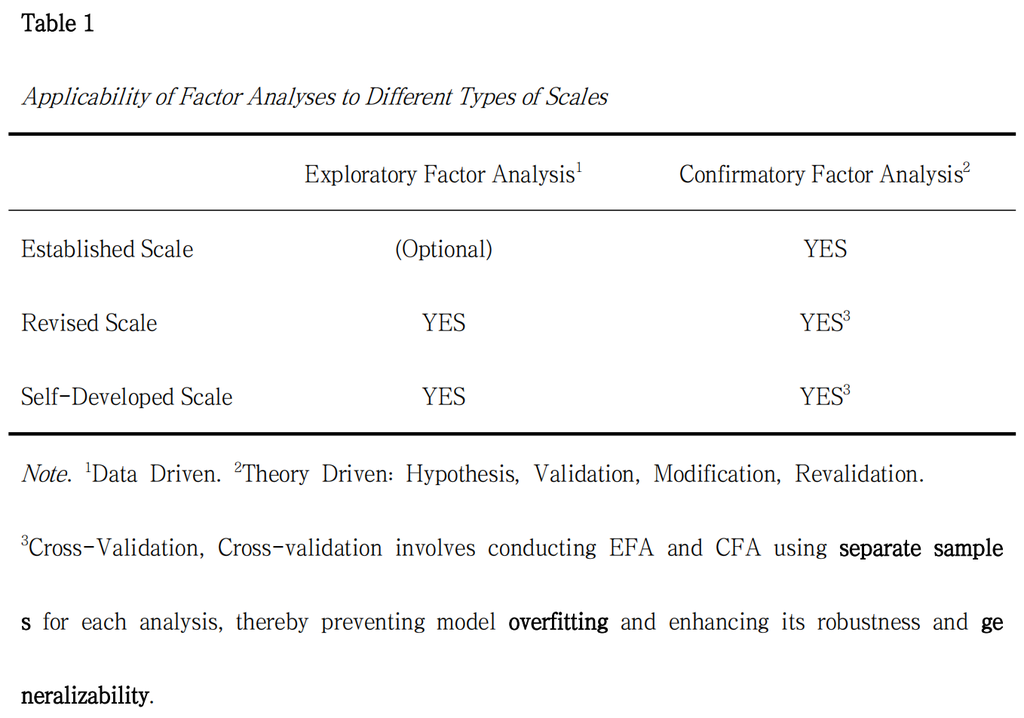

## 1.1 EFA

### 1.1.1 参考文献

- EFA-北京市排舞教练员胜任力模型构建研究_欧阳婷-P35
- EFA-新乡市初中体育教师职业声望的调查与提升研究_冯丽瑶-P19

### 1.1.2 样本量

为了确保EFA结果稳定可靠，有效样本数量建议同时满足以下4个标准：

- 样本数量 大于 题项数量
- 至少 **50个** 样本
- 最好是题项数量的 **5** 倍
- 为构建精确效度样本数量最好是 **150个** 以上

### 1.1.3 因子所辖题项数量

每个维度建议设计 **5个** 以上测量题项，在项目分析、EFA、CFA阶段均可能剔除部分题项，如果最终维度所辖题项数量 **小于3个** ，则该维度应考虑删除。

### 1.1.4 KMO和巴特利特球形度检验

KMO(Kaiser-Meyer-Olkin,取样适切性)

- KMO > 0.90 : 极适合
- KMO > 0.80 : 适合
- KMO > 0.70 : 尚可
- KMO > 0.60 : 勉强

巴特利特球形度(Bartlett’s Test of Sphericity)

- 原假设：相关系数矩阵对角线上所有元素均为1，其余元素均为0
- 检验结果 p < 0.05 表示原始变量存在相关性，数据适合作因子分析

### 1.1.5 设置因子提取方法和数量

因子提取方法（常用）

- 主成分:用最少的因子最大程度的解释原始数据的方差
- 主轴因式分解法：着重解释变量的相关性、确定内在结构，对于变量方差的解释不太重视，对于量表数据**维度的探索**，此方法更适合
- 最大似然法：大样本（n > 1500)更精确

因子提取数量

- 根据理论或实证事先确定
- 初始特征值大于1
- 碎石图辅助说明
- 累积方差百分比(自然科学:95%以上;社会科学:60%以上)

### 1.1.6 设置因子旋转方法

以因子载荷矩阵能够呈现清晰的、具有实际意义的因子结构为原则

- 最大方差法：最常用的正交旋转方法，尽量使用各因子的方差差异达到最大，方便因子命名
- 最优斜交法：最常用的斜交旋转方法，旋转后各因子相关系数不为0，通常情况下Kappa取默认值（4）即可

### 1.1.7 因子命名

确定因子结构后，根据每个因子题项内容结合专业知识进行命名

- 主成分+正交旋转：建议报告旋转后的成分矩阵
- 其他方法提取+正效旋转：建议报告旋转后的因子矩阵
- 斜交旋转：建议报告模式矩阵或结构矩阵

### 1.1.8 相关参数说明

- 公因子方差/共同度
  - 大于 0.5 应保留
  - 小于 0.2 建议剔除
- 特征值:因子解释的题项数量
- 累计方差贡献率:所有因子携带的题项信息
- 交叉载荷
  - 最大载荷应大于 0.5 ，第二载荷应小于 0.3 ，不满足此标准的题项建议剔除
  - 最大载荷值与第二载荷值之差的绝对值小于 0.1 ，该题项建议剔除
  - 最大载荷大于 0.5 ，具有实际意义

## 1.2 CFA

### 1.2.1 样本量

CFA需要样本量至少是题项数量的 10倍 以上

### 1.2.2 模型拟合

- 非标准化回归系数检验结果: p < 0.05
- 标准化因子载荷值: 0.5 ~ 0.95(0.71 ~ 0.95) 之间
- 常用拟合指标阈值

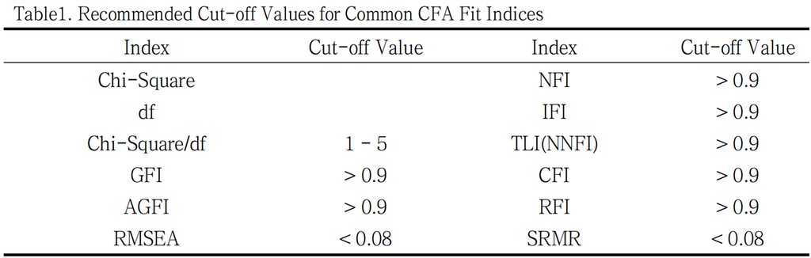

CFA案例模型拟合-R语言

```
##
##  CFA案例模型拟合
##
## Fit Measures (lavaan):
## χ²(181, N = 334) = 236.449, p = 0.004 **
## χ²/df = 1.306
## AIC = 21257.335 (Akaike Information Criterion)
## BIC = 21531.737 (Bayesian Information Criterion)
## CFI = 0.990 (Comparative Fit Index)
## TLI = 0.988 (Tucker-Lewis Index; Non-Normed Fit Index, NNFI)
## NFI = 0.960 (Normed Fit Index)
## IFI = 0.990 (Incremental Fit Index)
## GFI = 0.941 (Goodness-of-Fit Index)
## AGFI = 0.917 (Adjusted Goodness-of-Fit Index)
## RMSEA = 0.030, 90% CI [0.018, 0.041] (Root Mean Square Error of Approximation)
## SRMR = 0.025 (Standardized Root Mean Square Residual)
##
## Model Estimates (lavaan):
## ──────────────────────────────────────────────────────────────────────
##                    Estimate    S.E.      z     p      LLCI  ULCI  Beta
## ──────────────────────────────────────────────────────────────────────
## Latent Variables:
##   BI1 =~ bi1_1        1.000 (0.000)    Inf <.001 *** 1.000 1.000 0.810
##   BI1 =~ bi1_2        1.061 (0.066) 16.181 <.001 *** 0.932 1.189 0.820
##   BI1 =~ bi1_3        1.119 (0.066) 17.060 <.001 *** 0.991 1.248 0.870
##   BI2 =~ bi2_1        1.000 (0.000)    Inf <.001 *** 1.000 1.000 0.913
##   BI2 =~ bi2_2        1.004 (0.038) 26.487 <.001 *** 0.930 1.079 0.918
##   BI2 =~ bi2_3        0.956 (0.038) 25.096 <.001 *** 0.881 1.031 0.894
##   BI3 =~ bi3_1        1.000 (0.000)    Inf <.001 *** 1.000 1.000 0.926
##   BI3 =~ bi3_2        0.919 (0.033) 28.205 <.001 *** 0.855 0.983 0.921
##   BI3 =~ bi3_3        0.879 (0.033) 26.500 <.001 *** 0.814 0.944 0.897
##   PV1 =~ pv1_1        1.000 (0.000)    Inf <.001 *** 1.000 1.000 0.853
##   PV1 =~ pv1_2        1.148 (0.091) 12.674 <.001 *** 0.970 1.325 0.899
##   PV2 =~ pv2_1        1.000 (0.000)    Inf <.001 *** 1.000 1.000 0.870
##   PV2 =~ pv2_2        1.013 (0.085) 11.856 <.001 *** 0.846 1.181 0.854
##   PV3 =~ pv3_1        1.000 (0.000)    Inf <.001 *** 1.000 1.000 0.946
##   PV3 =~ pv3_2        0.807 (0.065) 12.468 <.001 *** 0.680 0.934 0.842
##   PV4 =~ pv4_1        1.000 (0.000)    Inf <.001 *** 1.000 1.000 0.856
##   PV4 =~ pv4_2        1.022 (0.088) 11.654 <.001 *** 0.850 1.194 0.911
##   LY =~ ly1           1.000 (0.000)    Inf <.001 *** 1.000 1.000 0.906
##   LY =~ ly2           0.991 (0.038) 25.979 <.001 *** 0.917 1.066 0.896
##   LY =~ ly3           1.004 (0.037) 27.208 <.001 *** 0.932 1.077 0.912
##   LY =~ ly4           0.977 (0.037) 26.491 <.001 *** 0.905 1.049 0.903
##   LY =~ ly5           0.964 (0.037) 26.287 <.001 *** 0.892 1.036 0.901
## ──────────────────────────────────────────────────────────────────────
## Note. Raw (Standard) Confidence Interval (CI) and SE.
```

## 1.3 R ShinyApps - EFA-CFA

[R ShinyApps - EFA-CFA](http://127.0.0.1:48579)